# Reproducible Research: Peer Assessment 1

Konstantin Serditov

9/16/2015

Load useful libraries:

```r
library(sqldf)
library(lattice)
```

## Loading and preprocessing the data

Load the data:

```r
data <- read.csv(file = "./activity.csv")
```

Convert “date” column to Date type:

```r
data[,2] <- as.Date(data[,2])
```

## What is mean total number of steps taken per day?

Ignoring the missing values in the dataset:

```r
meaningfuldata <- data[is.na(data$steps)==FALSE,]
```

1. Calculate the total number of steps taken per day:

```r
totals <- aggregate(meaningfuldata$steps, list(meaningfuldata$date), sum)
```

Barplot (shows distribution of total number of values by days):

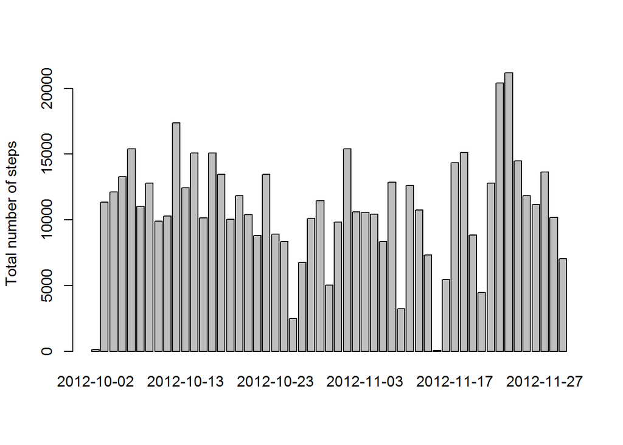

```r
barplot(totals$x, names.arg=(totals$Group.1), ylab = "Total number of steps")
```

2. Histogram (shows frequency of occurences of numbers of total values):

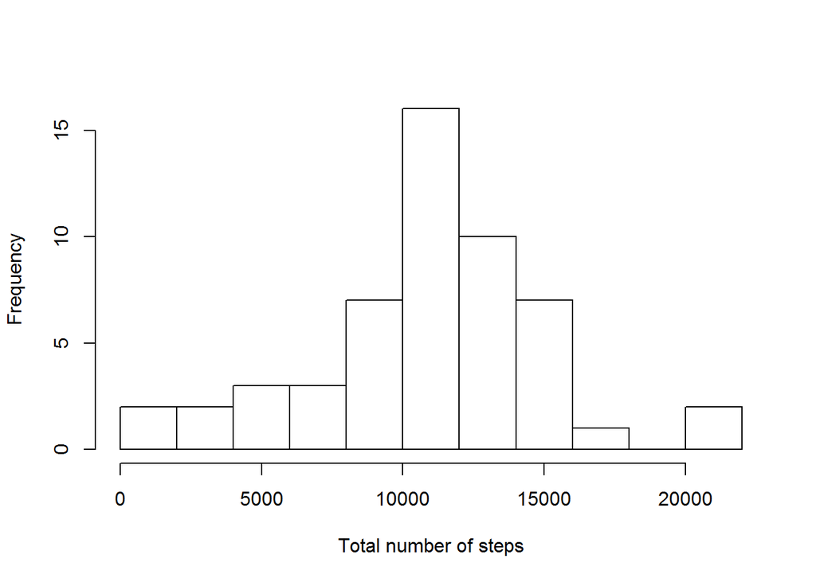

```r
hist(totals$x, breaks = 10, xlab = "Total number of steps", main=NULL)
```

3. For the total number of steps taken per day mean is `mean(totals$x)=`10766.1887 and median is `median(totals$x)=`10765.

## What is the average daily activity pattern?

1. Time series plot (i.e. type = “l”) of the 5-minute interval (x-axis) and the average number of steps taken, averaged across all days (y-axis):

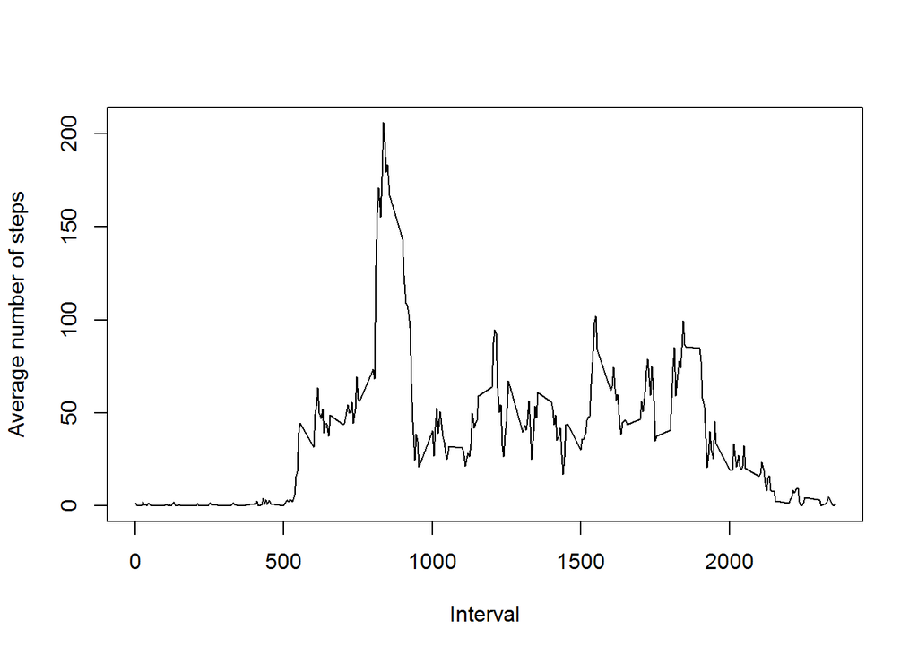

```r
avg_steps <- aggregate(meaningfuldata$steps, list(meaningfuldata$interval), mean)
plot(avg_steps$Group.1, avg_steps$x, type="l", xlab = "Interval", ylab = "Average number of steps")
```

2. Which 5-minute interval, on average across all the days in the dataset, contains the maximum number of steps?

```r
avg_steps[which.max(avg_steps$x),1]
```

```
## [1] 835
```

## Imputing missing values

1. Calculate and report the total number of missing values in the dataset (i.e. the total number of rows with NAs)

```r
sum(!complete.cases(data))
```

```
## [1] 2304
```

2. Devise a strategy for filling in all of the missing values in the dataset. The strategy does not need to be sophisticated. For example, you could use the mean/median for that day, or the mean for that 5-minute interval, etc.

[output not shown]

3. Create a new dataset that is equal to the original dataset but with the missing data filled in.

```r
inputed_data <- sqldf('
    select
        coalesce(a.steps, b.x) as steps,
        a.date,
        a.interval
    from data a
    left join avg_steps b
        on a.interval = b.[Group.1]
        and a.steps is null')
```

Check there is no NA anymore:

```r
sum(!complete.cases(inputed_data))
```

```
## [1] 0
```

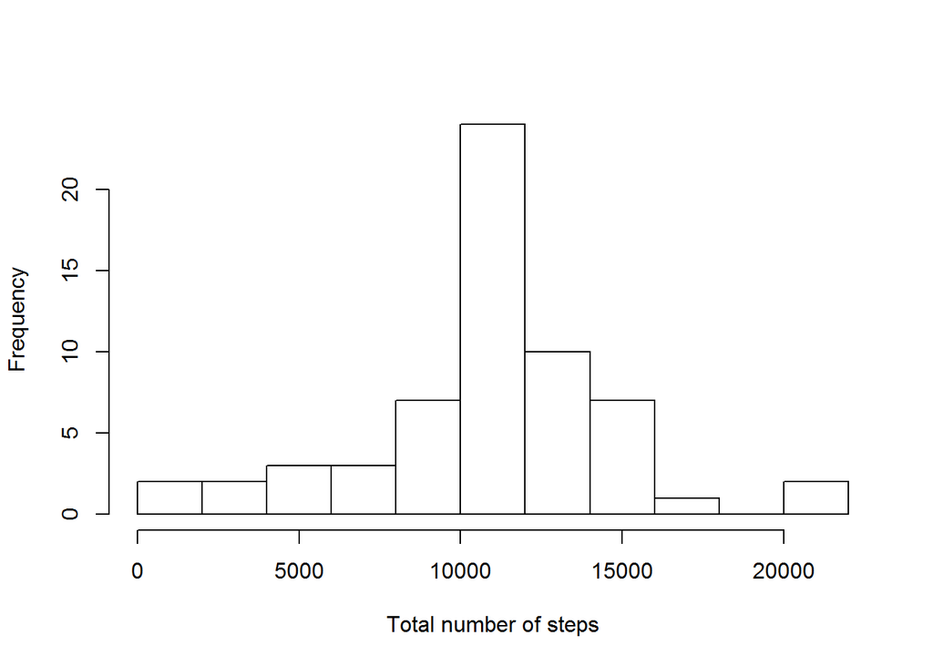

```r
inputed_totals <- aggregate(inputed_data$steps, list(inputed_data$date), sum)
hist(inputed_totals$x, breaks = 10, xlab = "Total number of steps", main=NULL)
```

## Are there differences in activity patterns between weekdays and weekends?

1. Create a new factor variable in the dataset with two levels – “weekday” and “weekend” indicating whether a given date is a weekday or weekend day.

```r
inputed_data[,2] <- as.Date(inputed_data[,2])

weekends <- c('суббота', 'воскресенье') # my 'weekdays' function returns result in russian - don't know how to change it
# use weekends <- c('sunday', 'saturday') if it doesn't work for you

inputed_data$weekday <- factor((weekdays(inputed_data$date) %in% weekends),
         levels=c(TRUE, FALSE), labels=c('weekend', 'weekday'))
```

2. Make a panel plot containing a time series plot (i.e. type = “l”) of the 5-minute interval (x-axis) and the average number of steps taken, averaged across all weekday days or weekend days (y-axis). See the README file in the GitHub repository to see an example of what this plot should look like using simulated data.

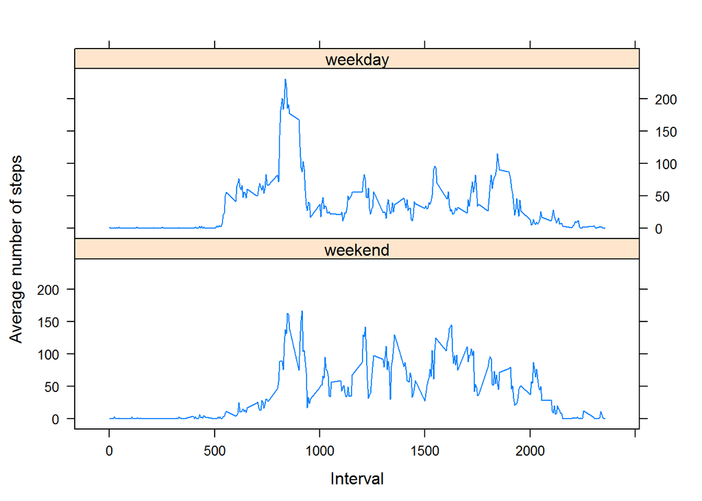

```r
inputed_avg_steps <- aggregate(inputed_data$steps, list(inputed_data$interval, inputed_data$weekday), mean)

xyplot(x ~ Group.1| Group.2, data = inputed_avg_steps, type = "l", layout=c(1,2), xlab = "Interval", ylab = "Average number of steps")
```